# **Qual o piloto mais rápido de Le Mans em 2022?**

## **Introdução**

Para criar a visualização, foi escolhido a base de dados do campeonato automobilístico de endurance da FIA (WEC), onde há 4 categorias de carros (Hypercar, LMP2, LMGTE Amador e LMGTE Profissional) correndo simultaneamente durante um longo período de tempo, sendo a prova com menor tempo de 6 horas e a de maior tempo, de 24 horas.

A base de dados foi encontrada no [Kaggle](https://www.kaggle.com/datasets/tristenterracciano/fia-wec-lap-data-20122022), com dados desde 2012 até 2022 de todas as voltas de cada etapa do campeonato.

```python
import matplotlib.pyplot as plt
import numpy as np
import pandas as pd
```

```python
#Import da base de dados
url = 'https://media.githubusercontent.com/media/adambry/Insper-DataScience-2023/main/2012-2022_FIA_WEC_FULL_LAP_DATA.csv'
df = pd.read_csv(url, index_col=0)
df.head()
```

|  | number | driver_number | lap_number | lap_time | lap_improvement | crossing_finish_line_in_pit | s1 | s1_improvement | s2 | s2_improvement | ... | team_stint | elapsed_ms | position | class_position | interval_ms | interval | gap | class_interval | class_gap | elapsed_s |
| --- | --- | --- | --- | --- | --- | --- | --- | --- | --- | --- | --- | --- | --- | --- | --- | --- | --- | --- | --- | --- | --- |
| 0 | 57 | 1 | 1 | 0 days 00:02:23.141000 | 0 | NaN | 52.533 | 0 | 45.335 | 0 | ... | Krohn Racing #57 Stint #1 | 143141 | 20.0 | 1.0 | 349.0 | 0.349 | 26.922 | 0.000 | 0.000 | 143.141 |
| 1 | 88 | 2 | 1 | 0 days 00:02:24.016000 | 0 | NaN | 52.915 | 0 | 45.342 | 0 | ... | Team Felbermayr-Proton #88 Stint #1 | 144016 | 21.0 | 2.0 | 875.0 | 0.875 | 27.797 | 0.875 | 0.875 | 144.016 |
| 2 | 50 | 2 | 1 | 0 days 00:02:25.278000 | 0 | NaN | 53.568 | 0 | 45.577 | 0 | ... | Larbre Competition #50 Stint #1 | 145278 | 22.0 | 3.0 | 1262.0 | 1.262 | 29.059 | 1.262 | 2.137 | 145.278 |
| 3 | 70 | 2 | 1 | 0 days 00:02:25.548000 | 0 | NaN | 53.938 | 0 | 45.614 | 0 | ... | Larbre Competition #70 Stint #1 | 145548 | 23.0 | 4.0 | 270.0 | 0.270 | 29.329 | 0.270 | 2.407 | 145.548 |
| 4 | 61 | 2 | 1 | 0 days 00:02:25.859000 | 0 | NaN | 54.482 | 0 | 45.816 | 0 | ... | AF Corse-Waltrip #61 Stint #1 | 145859 | 24.0 | 5.0 | 311.0 | 0.311 | 29.640 | 0.311 | 2.718 | 145.859 |

5 rows × 47 columns

Como há uma grande variedade de dados, a base foi filtrada com dados apenas do evento 24h de Le Mans (um dos eventos mais famosos da categoria endurance) na temporada de 2022, para realizar a análise.

```python
df_lemans = df[(df["circuit"] == "LE MANS") & (df["season"] == 2022)]
df_lemans.head()
```

|  | number | driver_number | lap_number | lap_time | lap_improvement | crossing_finish_line_in_pit | s1 | s1_improvement | s2 | s2_improvement | ... | team_stint | elapsed_ms | position | class_position | interval_ms | interval | gap | class_interval | class_gap | elapsed_s |
| --- | --- | --- | --- | --- | --- | --- | --- | --- | --- | --- | --- | --- | --- | --- | --- | --- | --- | --- | --- | --- | --- |
| 483178 | 8 | 1 | 1 | 0 days 00:03:58.487000 | 0 | NaN | 59.016 | 0 | 81.863 | 0 | ... | Toyota Gazoo Racing #8 Stint #1 | 238487 | 1.0 | 1.0 | 0.0 | 0.000 | 0.000 | 0.000 | 0.000 | 238.487 |
| 483179 | 7 | 1 | 1 | 0 days 00:03:59.536000 | 0 | NaN | 59.498 | 0 | 81.915 | 0 | ... | Toyota Gazoo Racing #7 Stint #1 | 239536 | 2.0 | 2.0 | 1049.0 | 1.049 | 1.049 | 1.049 | 1.049 | 239.536 |
| 483180 | 708 | 1 | 1 | 0 days 00:04:01.913000 | 0 | NaN | 60.159 | 0 | 81.956 | 0 | ... | Glickenhaus Racing #708 Stint #1 | 241913 | 3.0 | 3.0 | 2377.0 | 2.377 | 3.426 | 2.377 | 3.426 | 241.913 |
| 483181 | 709 | 3 | 1 | 0 days 00:04:03.814000 | 0 | NaN | 60.408 | 0 | 82.718 | 0 | ... | Glickenhaus Racing #709 Stint #1 | 243814 | 4.0 | 4.0 | 1901.0 | 1.901 | 5.327 | 1.901 | 5.327 | 243.814 |
| 483182 | 36 | 2 | 1 | 0 days 00:04:04.707000 | 0 | NaN | 60.945 | 0 | 83.809 | 0 | ... | Alpine ELF Team #36 Stint #1 | 244707 | 6.0 | 5.0 | 416.0 | 0.416 | 6.220 | 0.416 | 5.743 | 244.707 |

5 rows × 47 columns

Então, a escolha de gráfico a ser utilizado, foi o *stem*, onde será utilizado para visualizar o valor máximo de velocidade média de cada piloto dividido em cada classe, para ver quem teve a velocidade média mais alta em uma volta

Para realizar isso, será criado um dataframe novo, onde se agrupa a classe (coluna 'class') e o piloto (coluna 'driver_name') para descobrir o valor máximo de velocidade média.

```python
# Realiza a agregação dos valores máximos de kph por classe e nome do piloto
max_kph = df_lemans.groupby(['class', 'driver_name'])['kph'].max()
```

Como queremos criar um gráfico para cada classe, é necessário fazer uma lista de valores únicos de cada classe, para utilizar como argumento para o loop.

```python
# Criar um gráfico stem para cada classe
classes = df_lemans['class'].unique()
```

Então é feito o subplot e o loop para o plot dos gráficos por classe.

O loop utiliza *enumerate* das classes, onde ele retorna tanto o valor do index da classe quanto a classe em si. O index é utilizado para definir os eixos de cada gráfico, para ter os eixos corretos de cada classe.

Então, antes de realizar o plot, foram criadas 3 variáveis para facilitar a compreensão do código:

- *sub_df*: Dataframe com os nomes dos pilotos da classe e o valor máximo da velocidade média
- *driver_names*: Nome dos pilotos
- *kph_values*: Valores máximos da velocidade média

Assim é feito o gráfico *stem* com os atributos selecionados, iterando em cada classe.

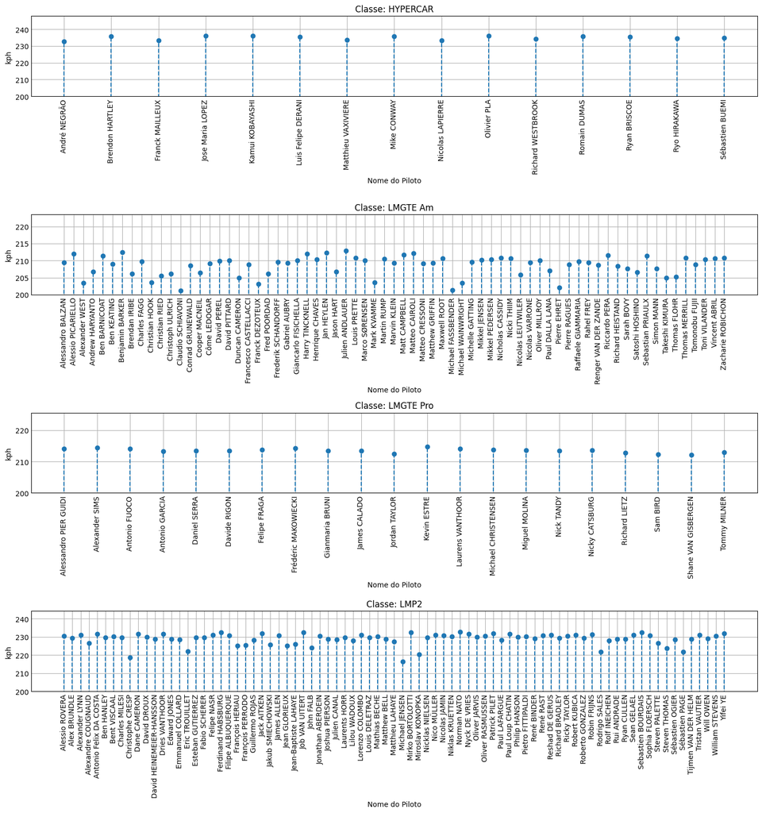

```python
# Criação do subplot, onde as linhas (nrows) são iguais ao número de classes
fig, axes = plt.subplots(nrows=len(classes), figsize=(15, 4 * len(classes)))

for i, classe in enumerate(classes):
    sub_df = max_kph[classe]
    driver_names = sub_df.index
    kph_values = sub_df.values

    axes[i].stem(driver_names, kph_values, linefmt="--")

    axes[i].set_title(f'Classe: {classe}') # Coloca o título de acordo com o nome da classe em loop
    axes[i].set_xlabel('Nome do Piloto')
    axes[i].set_ylabel('kph')
    axes[i].tick_params(axis='x', rotation=90) # Ajusta a legenda do eixo x dos pilotos para auxiliar a leitura
    axes[i].set_ylim(200, axes[i].get_ylim()[1])  # Define limite inferior do eixo y para o valor de 200 kph

plt.tight_layout() # Deixa o gráfico mais enxuto para evitar overlap
plt.show()
```

Podemos enriquecer esse plot destacando o piloto de cada classe que obteve a velocidade mais alta.

Para isso, será necessário resgatar o maior valor da variável *kph_values*, utilizando a função *argmax* para obter o índice do valor mais alto e com isso atribuir a lista *kph_values* para obter o maior valor.

Assim é feito "outro" gráfico stem, onde ele recebe os argumentos máximos para destacar apenas o valor máximo. Além disso, é utilizada a função *annotate* para mostrar o valor máximo encima do ponto.

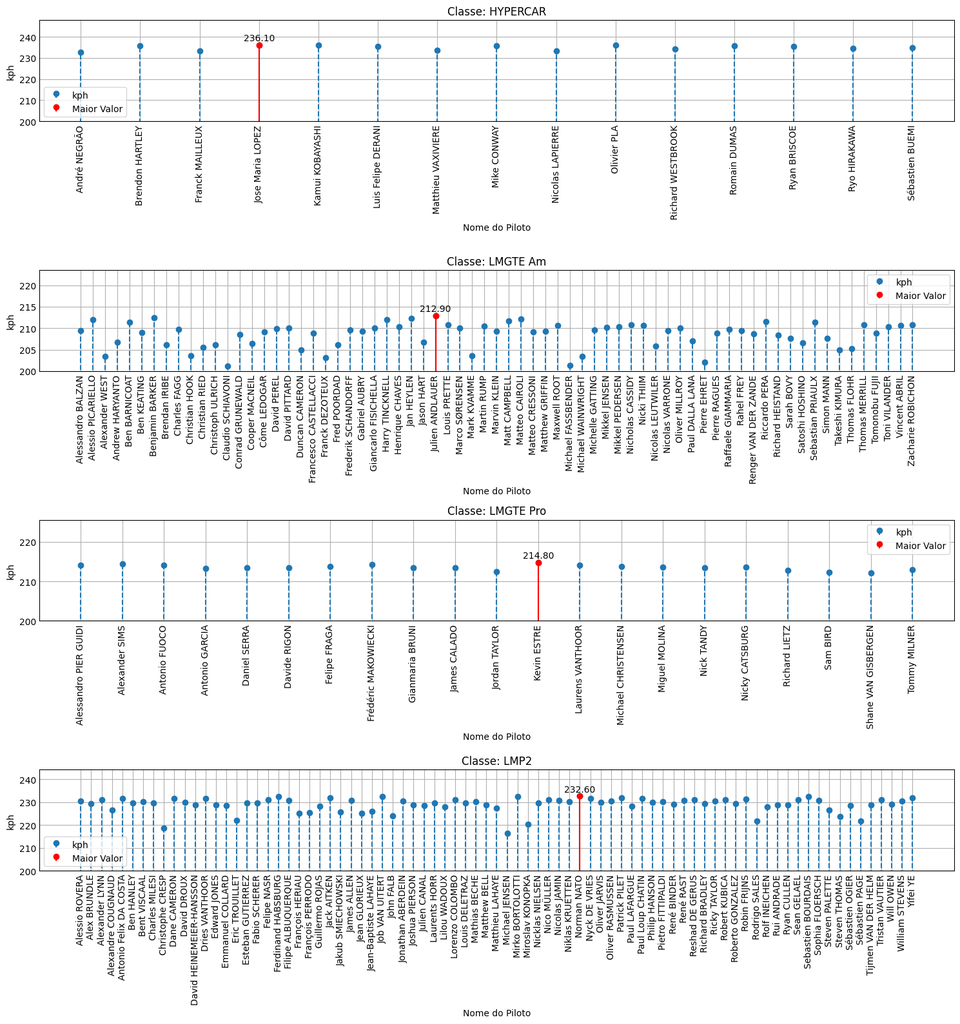

```python
# Criação do subplot, onde as linhas (nrows) são iguais ao número de classes
fig, axes = plt.subplots(nrows=len(classes), figsize=(15, 4 * len(classes)))

for i, classe in enumerate(classes):
    sub_df = max_kph[classe]
    driver_names = sub_df.index
    kph_values = sub_df.values

    max_idx = kph_values.argmax()  # Índice do maior valor
    max_kph_value = kph_values[max_idx]  # Maior valor de kph

    # Valores normais
    axes[i].stem(driver_names, kph_values, basefmt=" ", linefmt="--", label="kph")

    # Plot do maior valor
    axes[i].stem(driver_names[max_idx], max_kph_value, basefmt=" ", linefmt="r-", markerfmt="ro", label='Maior Valor')

    # Anotar o valor do maior ponto acima do marcador
    axes[i].annotate(f'{max_kph_value:.2f}', (driver_names[max_idx], max_kph_value),
                     textcoords="offset points", xytext=(0,5), ha='center')

    axes[i].set_title(f'Classe: {classe}')
    axes[i].set_xlabel('Nome do Piloto')
    axes[i].set_ylabel('kph')
    axes[i].tick_params(axis='x', rotation=90) # Ajusta a legenda do eixo x dos pilotos para auxiliar a leitura
    axes[i].set_ylim(200, axes[i].get_ylim()[1]) # Define limite inferior do eixo y para o valor de 200 kph
    axes[i].legend()


plt.tight_layout()
plt.show()
```